# R Intermediate Course 2026

2026-09-24

## Slides & Code

[figure not shown]

- *[f]* Full screen
- *[o]* Slide Overview
- *[c]* Notes
- *[h]* help

### git repo

[R-Intermediate](https://github.com/CECADBioinformaticsCoreFacility/Intermediate_R_Course_2026)

### Clone repo

`git clone https://github.com/CECADBioinformaticsCoreFacility/Intermediate_R_Course_2026.git`

### Slides Directly

https://cecadbioinformaticscorefacility.github.io/Intermediate_R_Course_2026/

**Session 2 :: Data Wrangling**

## From Base R to Tidyverse

**You already know how to work with data in R.** In the beginner course, we learned:

- Objects and data types
- Vectors, matrices and data frames
- `[]`, `[[]]` and `$`
- Conditional statements
- Loops and apply()
- Basic data manipulation
  - `reshape()`
  - `stack() / unstack()`
  - `cbind() / rbind()`
  - `merge()`

[figure not shown]

[figure not shown]

**Now we ask a different question:**

**How can we express data analysis in a clear, readable and reproducible way?**

Enter the tidyverse →

## `Tidyverse`

[figure not shown]

`tidyverse` is an ecosystem of packages that work together to make data science easier and more efficient in R.

Some of the most popular packages in the tidyverse include:

- `readr` for data import
- `tidyr` for data tidying
- `tibble` for enhanced data frames
- `dplyr` for data manipulation
- `stringr` for string manipulation
- `forcats` for working with categorical variables (factors)
- `lubridate` for working with dates and times
- `ggplot2` for data visualization
- `purrr` for functional programming

Learn the tidyverse [R for Data Science (2e)](https://r4ds.hadley.nz/)

## Why `Tidyverse` for Bioinformatics?

Real biological datasets are rarely ready for analysis.

You constantly need to:

- Select samples
- Filter genes
- Create annotations
- Combine metadata
- Summarize replicates
- Reshape tables
- Join results from different analyses

Tidyverse gives us a common language for manipulating biological data.

**Don’t Forget Base R!**

**Tidyverse is not a replacement for Base R**

You will encounter both styles in real-world R code.

Understanding Base R makes you a better Tidyverse programmer.

[figure not shown]

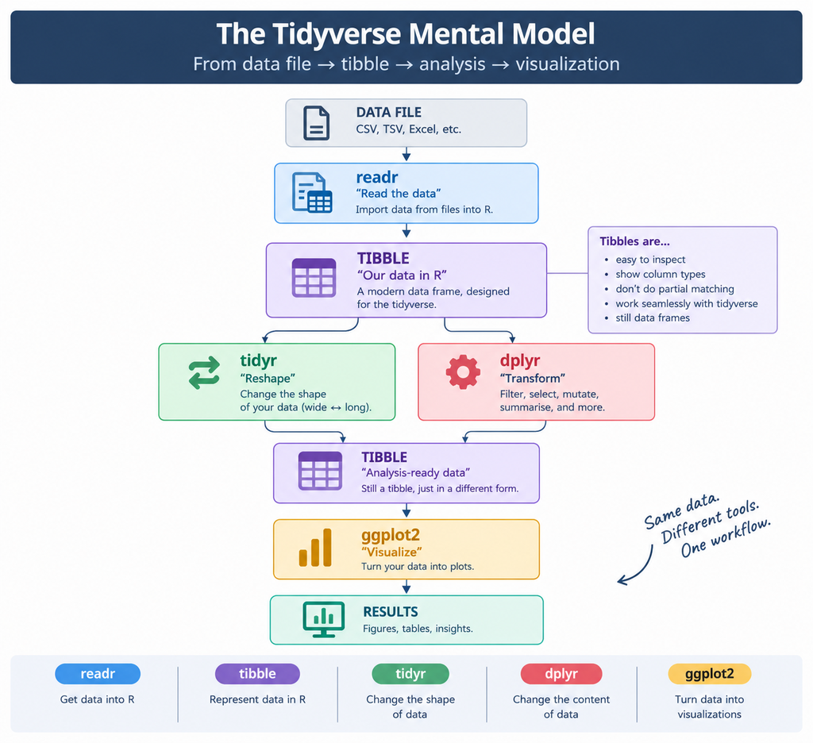

## tidy data

Tidy data <sup>1</sup> is a standardized way of organizing data values within a dataset. In tidy data:

This structure makes it easier to manipulate, analyze, and visualize data.

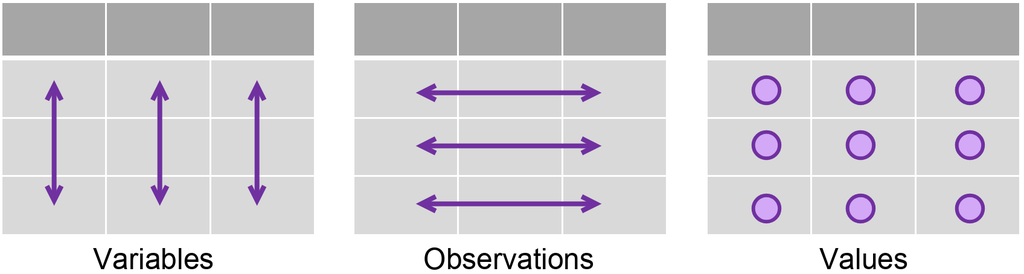

[^1]: R for Data Science (2e)

## Why `readr`?

**Problem at hand**

**Getting your data into R is part of the analysis**

**Base R:**

```r
df <- read.csv("rna_results.csv")
```

**readr:**

```r
library(readr)

df <- read_csv("rna_results.csv")
```

Common files:

- CSV -> comma-separated `read_csv(), readr::read_csv_chunked()`
- TSV -> tab-separated `read_tsv(),read_tsv_chunked()`
- TXT -> delimited text `read_delim()`

**Why use `readr`?**

- Fast for large files; One can use chunks or multi threads
- Better parsing and type detection
- Clear messages about how columns were interpreted
- Consistent with the tidyverse
- Produces tibbles that work naturally with tidyverse tools

*`readr` makes importing and exporting rectangular data predictable and transparent.*

More on [Importing data with the tidyverse](https://opensource.posit.co/resources/cheatsheets/data-import/data-import.pdf)

## Why `tibble`?

```r
iris
```

```
    Sepal.Length Sepal.Width Petal.Length Petal.Width    Species
1            5.1         3.5          1.4         0.2     setosa
2            4.9         3.0          1.4         0.2     setosa
3            4.7         3.2          1.3         0.2     setosa
4            4.6         3.1          1.5         0.2     setosa
5            5.0         3.6          1.4         0.2     setosa
6            5.4         3.9          1.7         0.4     setosa
7            4.6         3.4          1.4         0.3     setosa
8            5.0         3.4          1.5         0.2     setosa
9            4.4         2.9          1.4         0.2     setosa
10           4.9         3.1          1.5         0.1     setosa
11           5.4         3.7          1.5         0.2     setosa
12           4.8         3.4          1.6         0.2     setosa
13           4.8         3.0          1.4         0.1     setosa
14           4.3         3.0          1.1         0.1     setosa
```

[output cut: 136 more lines]

```r
tibble::tibble(iris)
```

```
# A tibble: 150 × 5
   Sepal.Length Sepal.Width Petal.Length Petal.Width Species
          <dbl>       <dbl>        <dbl>       <dbl> <fct>
 1          5.1         3.5          1.4         0.2 setosa
 2          4.9         3            1.4         0.2 setosa
 3          4.7         3.2          1.3         0.2 setosa
 4          4.6         3.1          1.5         0.2 setosa
 5          5           3.6          1.4         0.2 setosa
 6          5.4         3.9          1.7         0.4 setosa
 7          4.6         3.4          1.4         0.3 setosa
 8          5           3.4          1.5         0.2 setosa
 9          4.4         2.9          1.4         0.2 setosa
10          4.9         3.1          1.5         0.1 setosa
# ℹ 140 more rows
```

`tibbles` are designed to make working with data safer and easier to inspect.

**Note**

*You immediately see:*

1. Number of rows
2. Number of columns
3. Column names
4. Column types
5. A preview of the data

*Why use `tibble`*

1. A `tibble` is a data frame.
2. `tibbles` print data in a human-friendly way.
3. `tibbles` are stricter and more predictable in some situations.
4. `tibbles` are the natural data object of the tidyverse.

Don’t think of `tibble` as another complicated thing to learn. Think of it as the tidyverse’s modern data frame.

## Why `tidyr`?

**Real-world data are often not in the right shape.** Biological data frequently come in formats that are:

- Wide when we need long
- Long when we need wide
- Spread across multiple columns
- Packed with multiple values in one column

*Wide → Long*

```r
iris_filtered <- iris |>
  filter(Sepal.Length > 7) |>
  mutate(ID = row_number())

 iris_filtered
```

```
   Sepal.Length Sepal.Width Petal.Length Petal.Width   Species ID
1           7.1         3.0          5.9         2.1 virginica  1
2           7.6         3.0          6.6         2.1 virginica  2
3           7.3         2.9          6.3         1.8 virginica  3
4           7.2         3.6          6.1         2.5 virginica  4
5           7.7         3.8          6.7         2.2 virginica  5
6           7.7         2.6          6.9         2.3 virginica  6
7           7.7         2.8          6.7         2.0 virginica  7
8           7.2         3.2          6.0         1.8 virginica  8
9           7.2         3.0          5.8         1.6 virginica  9
10          7.4         2.8          6.1         1.9 virginica 10
11          7.9         3.8          6.4         2.0 virginica 11
12          7.7         3.0          6.1         2.3 virginica 12
```

## Why `tidyr`?

**Real-world data are often not in the right shape.** Biological data frequently come in formats that are:

- Wide when we need long
- Long when we need wide
- Spread across multiple columns
- Packed with multiple values in one column

*Wide → Long*

```r
iris_filtered <- iris |>
  filter(Sepal.Length > 7) |>
  mutate(ID = row_number())

 iris_filtered
```

```
   Sepal.Length Sepal.Width Petal.Length Petal.Width   Species ID
1           7.1         3.0          5.9         2.1 virginica  1
2           7.6         3.0          6.6         2.1 virginica  2
3           7.3         2.9          6.3         1.8 virginica  3
4           7.2         3.6          6.1         2.5 virginica  4
5           7.7         3.8          6.7         2.2 virginica  5
6           7.7         2.6          6.9         2.3 virginica  6
7           7.7         2.8          6.7         2.0 virginica  7
8           7.2         3.2          6.0         1.8 virginica  8
9           7.2         3.0          5.8         1.6 virginica  9
10          7.4         2.8          6.1         1.9 virginica 10
11          7.9         3.8          6.4         2.0 virginica 11
12          7.7         3.0          6.1         2.3 virginica 12
```

## Why `tidyr`?

**Real-world data are often not in the right shape.** Biological data frequently come in formats that are:

- Wide when we need long
- Long when we need wide
- Spread across multiple columns
- Packed with multiple values in one column

*Wide → Long*

```r
long_base <- reshape(
  iris_filtered,
  varying = c(
    "Sepal.Length", "Sepal.Width", "Petal.Length", "Petal.Width"
  ),
  v.names = "Value",
  timevar = "Measurement",
  times = c(
    "Sepal.Length", "Sepal.Width", "Petal.Length", "Petal.Width"
  ),
  idvar = "ID",
  direction = "long"
)

long_base
```

```
                  Species ID  Measurement Value
1.Sepal.Length  virginica  1 Sepal.Length   7.1
2.Sepal.Length  virginica  2 Sepal.Length   7.6
3.Sepal.Length  virginica  3 Sepal.Length   7.3
4.Sepal.Length  virginica  4 Sepal.Length   7.2
5.Sepal.Length  virginica  5 Sepal.Length   7.7
6.Sepal.Length  virginica  6 Sepal.Length   7.7
7.Sepal.Length  virginica  7 Sepal.Length   7.7
8.Sepal.Length  virginica  8 Sepal.Length   7.2
9.Sepal.Length  virginica  9 Sepal.Length   7.2
10.Sepal.Length virginica 10 Sepal.Length   7.4
11.Sepal.Length virginica 11 Sepal.Length   7.9
12.Sepal.Length virginica 12 Sepal.Length   7.7
1.Sepal.Width   virginica  1  Sepal.Width   3.0
2.Sepal.Width   virginica  2  Sepal.Width   3.0
3.Sepal.Width   virginica  3  Sepal.Width   2.9
4.Sepal.Width   virginica  4  Sepal.Width   3.6
5.Sepal.Width   virginica  5  Sepal.Width   3.8
6.Sepal.Width   virginica  6  Sepal.Width   2.6
7.Sepal.Width   virginica  7  Sepal.Width   2.8
8.Sepal.Width   virginica  8  Sepal.Width   3.2
9.Sepal.Width   virginica  9  Sepal.Width   3.0
10.Sepal.Width  virginica 10  Sepal.Width   2.8
11.Sepal.Width  virginica 11  Sepal.Width   3.8
12.Sepal.Width  virginica 12  Sepal.Width   3.0
1.Petal.Length  virginica  1 Petal.Length   5.9
2.Petal.Length  virginica  2 Petal.Length   6.6
3.Petal.Length  virginica  3 Petal.Length   6.3
4.Petal.Length  virginica  4 Petal.Length   6.1
5.Petal.Length  virginica  5 Petal.Length   6.7
6.Petal.Length  virginica  6 Petal.Length   6.9
7.Petal.Length  virginica  7 Petal.Length   6.7
8.Petal.Length  virginica  8 Petal.Length   6.0
9.Petal.Length  virginica  9 Petal.Length   5.8
10.Petal.Length virginica 10 Petal.Length   6.1
11.Petal.Length virginica 11 Petal.Length   6.4
12.Petal.Length virginica 12 Petal.Length   6.1
1.Petal.Width   virginica  1  Petal.Width   2.1
2.Petal.Width   virginica  2  Petal.Width   2.1
3.Petal.Width   virginica  3  Petal.Width   1.8
4.Petal.Width   virginica  4  Petal.Width   2.5
5.Petal.Width   virginica  5  Petal.Width   2.2
6.Petal.Width   virginica  6  Petal.Width   2.3
7.Petal.Width   virginica  7  Petal.Width   2.0
8.Petal.Width   virginica  8  Petal.Width   1.8
9.Petal.Width   virginica  9  Petal.Width   1.6
10.Petal.Width  virginica 10  Petal.Width   1.9
11.Petal.Width  virginica 11  Petal.Width   2.0
12.Petal.Width  virginica 12  Petal.Width   2.3
```

```r
long <- iris_filtered |>
  pivot_longer(
    cols = c(Sepal.Length, Sepal.Width, Petal.Length, Petal.Width),
    names_to = "Measurement",
    values_to = "Value"
  )

long
```

```
# A tibble: 48 × 4
   Species      ID Measurement  Value
   <fct>     <int> <chr>        <dbl>
 1 virginica     1 Sepal.Length   7.1
 2 virginica     1 Sepal.Width    3
 3 virginica     1 Petal.Length   5.9
 4 virginica     1 Petal.Width    2.1
 5 virginica     2 Sepal.Length   7.6
 6 virginica     2 Sepal.Width    3
 7 virginica     2 Petal.Length   6.6
 8 virginica     2 Petal.Width    2.1
 9 virginica     3 Sepal.Length   7.3
10 virginica     3 Sepal.Width    2.9
# ℹ 38 more rows
```

## Why `tidyr`?

**Real-world data are often not in the right shape.** Biological data frequently come in formats that are:

- Wide when we need long
- Long when we need wide
- Spread across multiple columns
- Packed with multiple values in one column

*Long → Wide*

```r
wide_base <- reshape(
  long_base,
  idvar = "ID",
  timevar = "Measurement",
  direction = "wide"
)

wide_base |> head()
```

```
               ID Species.Sepal.Length Value.Sepal.Length Species.Sepal.Width
1.Sepal.Length  1            virginica                7.1           virginica
2.Sepal.Length  2            virginica                7.6           virginica
3.Sepal.Length  3            virginica                7.3           virginica
4.Sepal.Length  4            virginica                7.2           virginica
5.Sepal.Length  5            virginica                7.7           virginica
6.Sepal.Length  6            virginica                7.7           virginica
               Value.Sepal.Width Species.Petal.Length Value.Petal.Length
1.Sepal.Length               3.0            virginica                5.9
2.Sepal.Length               3.0            virginica                6.6
3.Sepal.Length               2.9            virginica                6.3
4.Sepal.Length               3.6            virginica                6.1
5.Sepal.Length               3.8            virginica                6.7
6.Sepal.Length               2.6            virginica                6.9
               Species.Petal.Width Value.Petal.Width
1.Sepal.Length           virginica               2.1
2.Sepal.Length           virginica               2.1
3.Sepal.Length           virginica               1.8
4.Sepal.Length           virginica               2.5
5.Sepal.Length           virginica               2.2
6.Sepal.Length           virginica               2.3
```

```r
wide <- long |>
  pivot_wider(
    names_from = Measurement,
    values_from = Value
  )

wide |> head()
```

```
# A tibble: 6 × 6
  Species      ID Sepal.Length Sepal.Width Petal.Length Petal.Width
  <fct>     <int>        <dbl>       <dbl>        <dbl>       <dbl>
1 virginica     1          7.1         3            5.9         2.1
2 virginica     2          7.6         3            6.6         2.1
3 virginica     3          7.3         2.9          6.3         1.8
4 virginica     4          7.2         3.6          6.1         2.5
5 virginica     5          7.7         3.8          6.7         2.2
6 virginica     6          7.7         2.6          6.9         2.3
```

**Why use `tidyr`?**

*`tidyr` changes the shape of your data without changing the information.*

More on [Data tidying with tidyr](https://opensource.posit.co/resources/cheatsheets/tidyr/tidyr.pdf)

## The Power of the Pipe `|>` or `%>%`

- `|>` or `%>%` operators allow you to pass the output of one function as the input to another function, making your code more readable and concise. Simply saying, chain multiple operations together.

[figure not shown]

[figure not shown]

[figure not shown]

[figure not shown]

[figure not shown]

[figure not shown]

[figure not shown]

[figure not shown]

[figure not shown]

[figure not shown]

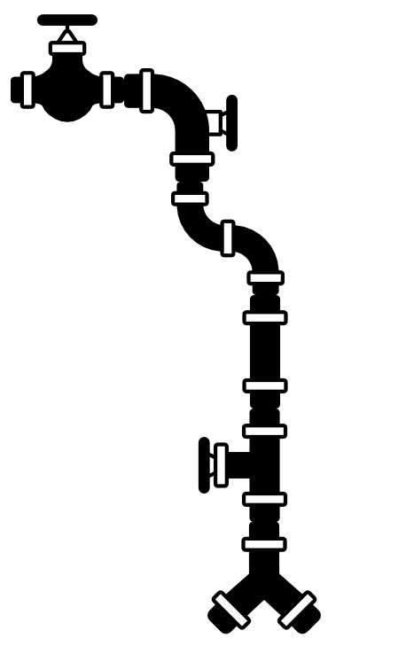

## The Power of the Pipe `|>` or `%>%`

Consider a typical RNA-Seq analysis:

[output not shown]

```r
res |>
  filter(!is.na(padj),
         padj < 0.05) |>
  mutate(
    direction = if_else(
      log2FoldChange > 0,
      "Up",
      "Down"
    )
  ) |>
  arrange(desc(abs(log2FoldChange))) |>
  select(gene, log2FoldChange, padj, direction)
```

**Note**

*The code follows the logic of the analysis.*

## Why `dplyr`?

**A grammar for data manipulation**

Instead of thinking about complicated indexing:

```r
df[df$group == "Control", ]
```

we can describe what we want:

```r
df |>
  filter(group == "Control")
```

**The key idea**

Use a small number of verbs to describe what you want to do to your data.

| Task | dplyr verb |
| --- | --- |
| Choose rows | `filter()` |
| Choose columns | `select()` |
| Create/change columns | `mutate()` |
| Summarize | `summarise()` |
| Group | `group_by()` |
| Sort | `arrange()` |
| Combine datasets | `*_join()` |

More on [Data transformation with dplyr](https://opensource.posit.co/resources/cheatsheets/data-transformation/data-transformation.pdf)

## Data Reshaping in Base R vs dplyr

```r
# 1. Filter rows, select columns, and create the new column
sub_iris <- subset(iris,
  Sepal.Length > 5,
  select = c(Sepal.Length, Petal.Length, Species)
  )
sub_iris$SePa.Length <- sub_iris$Sepal.Length + sub_iris$Petal.Length

# 2. Sort rows in descending order of the new column
sub_iris <- sub_iris[order(-sub_iris$SePa.Length), ]

# 3. Group by Species and calculate mean and count (n)
result <- aggregate(SePa.Length ~ Species,
  data = sub_iris,
  FUN = function(x) {
  c(mean = mean(x), n = length(x))
})

# 4. Flatten the matrix column produced by aggregate into a clean data frame
result <- do.call(data.frame, result)
names(result) <- c("Species", "mean", "n")

print(result)
```

```
     Species      mean  n
1     setosa  6.822727 22
2 versicolor 10.314894 47
3  virginica 12.195918 49
```

```r
library(dplyr)
iris |>
   filter(Sepal.Length > 5) |>                          # filter rows
   select(Sepal.Length, Petal.Length, Species) |>       # select columns
   mutate(SePa.Length=Sepal.Length+Petal.Length) |>     # add new column
   arrange(desc(SePa.Length)) |>                        # sort rows
   group_by(Species) |>                                 # group by Species
   summarise(mean = mean(SePa.Length), n = n())         # summarise
```

```
# A tibble: 3 × 3
  Species     mean     n
  <fct>      <dbl> <int>
1 setosa      6.82    22
2 versicolor 10.3     47
3 virginica  12.2     49
```

## Pick columns using `dplyr::select()`

- Visual
- Code

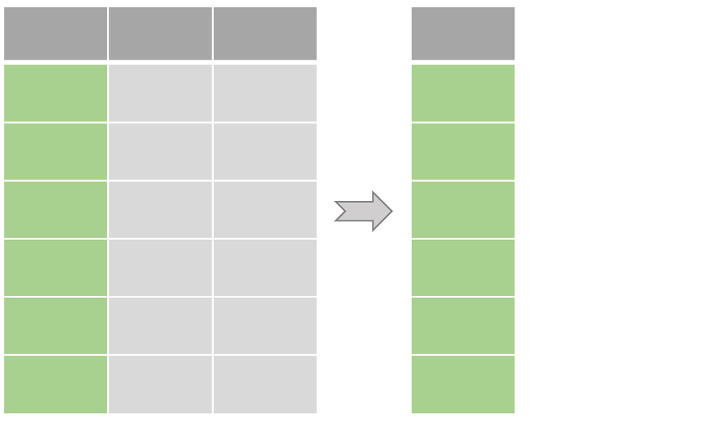

#### base-r

#### dplyr

**select specific columns by name**

`select(iris,Sepal.Length, Petal.Length, Species)`

**select specific columns by position**

`iris[,c(1,2,3)]`

`select(iris,1,2,3)`

**select a range of columns by position**

`iris[,c(1:3)]`

`select(iris,1:3)`

**exclude specific columns by position**

`iris[,-c(1,2)]`

**reorder columns**

`iris[,c("Species","Sepal.Length", "Petal.Length")]`

`select(iris,Species, Sepal.Length, Petal.Length)`

**Note**

## Pick rows Using `dplyr::slice()`

- Visual
- Code

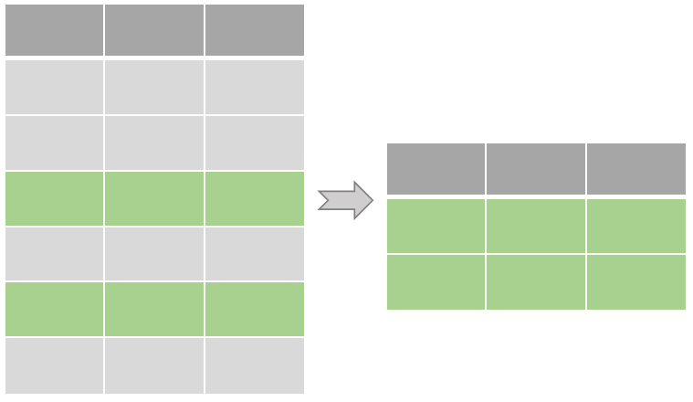

#### base-r

#### dplyr

**get specific rows**

`iris[c(1,3,5,7),]`

`slice(iris,c(1,3,5,7))`

**get rows by range**

`iris[10:20,]`

`slice(iris,10:20)`

**get first 10 rows**

`iris[1:10,]` `head(iris, 10)`

`slice((1:10)` `slice_head(iris, n = 10)`

**get last 10 rows**

`tail(iris, 10)`

`slice((n()-9):n())` or `slice_tail(iris, n = 10)`

**Note**

- `slice()` selects rows by row number, not based on conditions.

## Functional row selection with `filter()`

- Visual
- Code

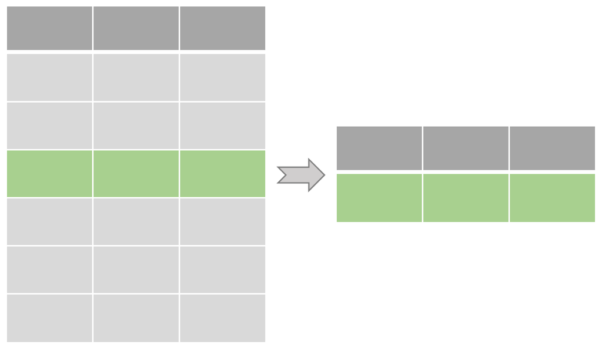

#### base-r

#### dplyr

**Select a conditional parameter**

`iris[iris$Sepal.Length > 7,]`

`filter(iris,Sepal.Length > 7)`

**match values in a vector**

`iris[iris$Sepal.Length %in% c(5.0, 5.1), ]`

`filter(iris, Sepal.Length %in% c(5.0, 5.1))`

`iris[is.na(iris$Sepal.Length), ]`

`filter(iris, is.na(Sepal.Length) )`

**Select a conditional parameter for abs()**

`iris[abs(iris$Sepal.Length - 5) < 0.1, ]`

`filter(iris, abs(Sepal.Length - 5) < 0.1 )`

**Filter rows base on pattern matching**

`iris[grepl("ver", iris$Species), ]`

`filter(iris, grepl("ver", Species))`

**Note**

- `filter()` selects rows based on conditions. `&` and `|` are not same as `&&` and `||`.

## `mutate()` & `transmute()` to add or transform columns

- Visual
- Code

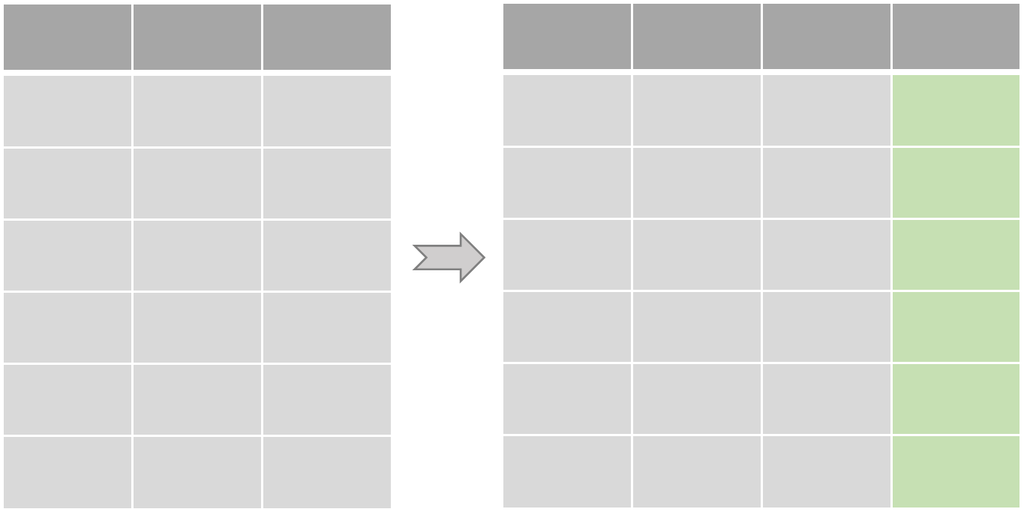

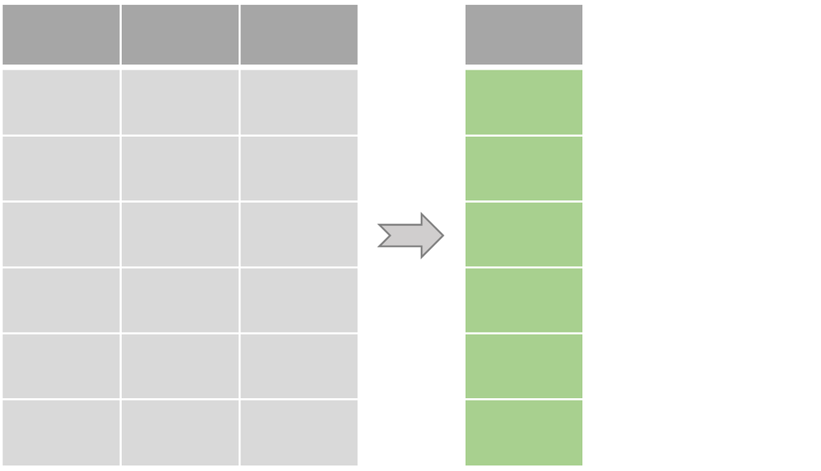

#### base-r

#### dplyr

**Add new column**

`iris$Sepa.Length <- iris$Sepal.Length + iris$Petal.Length`

`mutate(iris,SePa.Length=Sepal.Length+Petal.Length)`

**create new column and drop others**

`with(iris, data.frame(SePa.Length=ifelse(Sepal.Length > 5, "Long", "Short")))`

`transmute(iris,SePa.Length=ifelse(Sepal.Length > 5, "Long", "Short"))`

## arrange (sorting)

- Visual
- Code

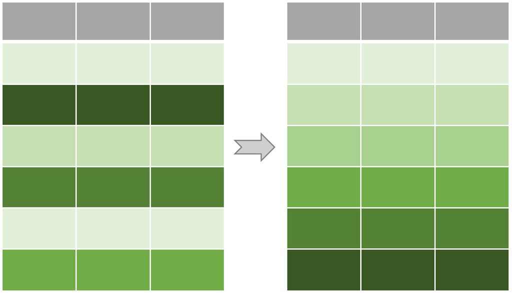

#### base-r

#### dplyr

**sort by ascending order**

`iris[order(iris$Sepal.Length, iris$Petal.Length), ]`

`arrange(iris, Sepal.Length, Petal.Length)`

**sort by descending order**

`iris[order(-iris$Sepal.Length, -iris$Petal.Length), ]`

`arrange(iris,desc(Sepal.Length), desc(Petal.Length))`

## group_by + summarise (aggregation)

- Visual
- Code

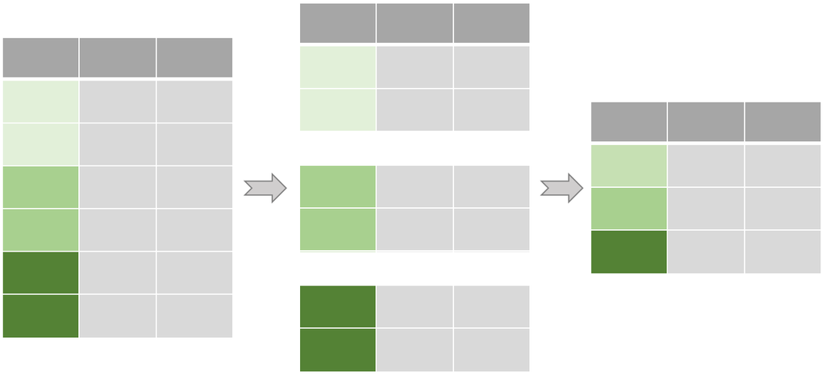

#### base-r

#### dplyr

```r
aggregate(cbind(Petal.Length, Sepal.Length) ~ Species + Petal.Width,
data = iris,
FUN = function(x) { c(mean = mean(x), n = length(x))
})
```

```
      Species Petal.Width Petal.Length.mean Petal.Length.n Sepal.Length.mean
1      setosa         0.1          1.380000       5.000000          4.820000
2      setosa         0.2          1.444828      29.000000          4.972414
3      setosa         0.3          1.428571       7.000000          4.971429
4      setosa         0.4          1.571429       7.000000          5.300000
5      setosa         0.5          1.700000       1.000000          5.100000
6      setosa         0.6          1.600000       1.000000          5.000000
7  versicolor         1.0          3.628571       7.000000          5.414286
8  versicolor         1.1          3.566667       3.000000          5.400000
9  versicolor         1.2          4.240000       5.000000          5.780000
10 versicolor         1.3          4.176923      13.000000          5.884615
11 versicolor         1.4          4.500000       7.000000          6.357143
12  virginica         1.4          5.600000       1.000000          6.100000
13 versicolor         1.5          4.580000      10.000000          6.190000
14  virginica         1.5          5.050000       2.000000          6.150000
```

[output cut: 41 more lines]

```r
iris %>%
  group_by(Species,Petal.Width) %>%
  summarise(mean = mean(Petal.Length), mean2 = mean(Sepal.Length) , n = n()) %>%
  ungroup()
```

```
# A tibble: 27 × 5
   Species    Petal.Width  mean mean2     n
   <fct>            <dbl> <dbl> <dbl> <int>
 1 setosa             0.1  1.38  4.82     5
 2 setosa             0.2  1.44  4.97    29
 3 setosa             0.3  1.43  4.97     7
 4 setosa             0.4  1.57  5.3      7
 5 setosa             0.5  1.7   5.1      1
 6 setosa             0.6  1.6   5        1
 7 versicolor         1    3.63  5.41     7
 8 versicolor         1.1  3.57  5.4      3
 9 versicolor         1.2  4.24  5.78     5
10 versicolor         1.3  4.18  5.88    13
# ℹ 17 more rows
```

## distinct (deduplication)

- Visual
- Code

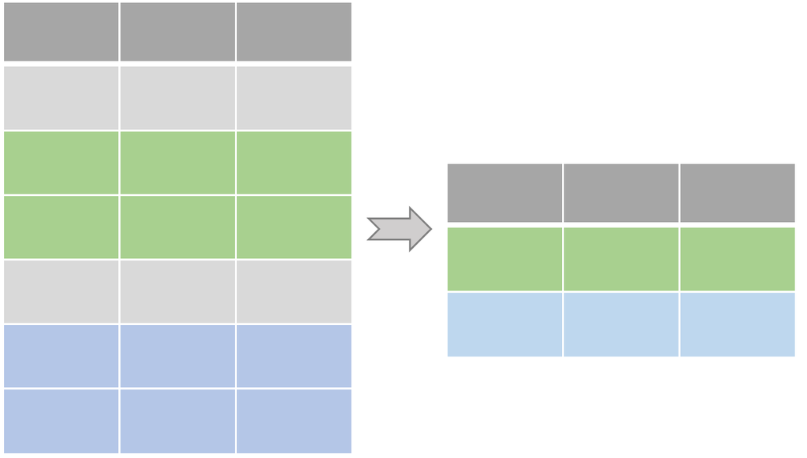

#### base-r

#### dplyr

**return unique rows**

`unique(iris["Species"])` or `unique(iris$Species)`

`distinct(iris,Species)`

**return unique rows based on Index column and keep all other columns**

`iris[!duplicated(iris$Species), ]`

`distinct(iris,Species,.keep_all= TRUE)`

## `bind_cols()` & `bind_rows()`

- Visual
- Code

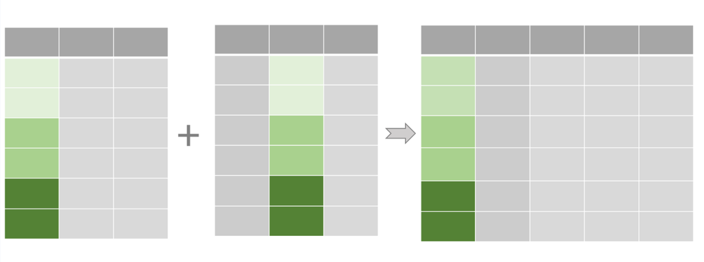

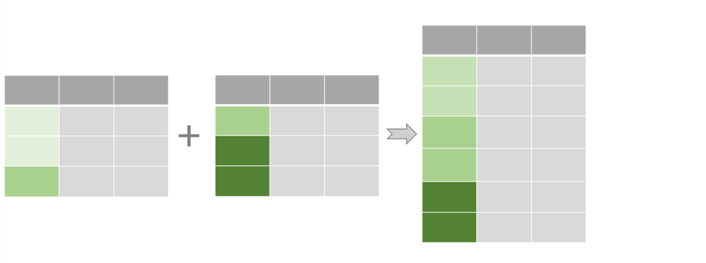

#### base-r

#### dplyr

**Horizontal Binding**

`cbind(df_long, df_short)`

`bind_cols(df_long, df_short)`

**Vertical Binding**

`rbind(df1, df2)`

`bind_rows(df1, df2)`

## `join()` function

- Visual
- Code

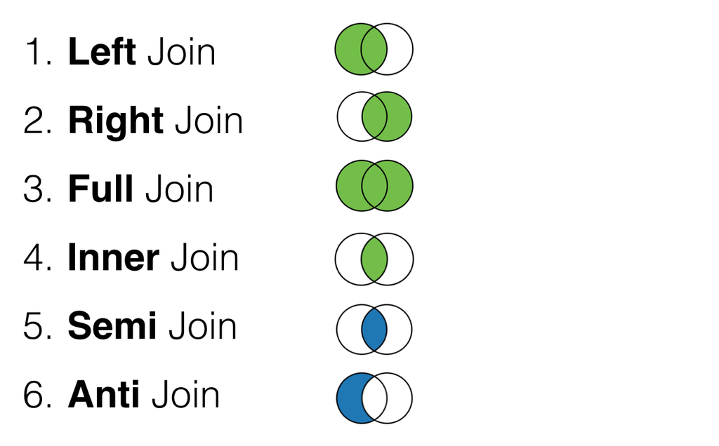

#### base-r

#### dplyr

**Left Join**

`merge(x, y, all.x = TRUE)`

`left_join(x, y)`

**Right Join**

`merge(x, y, all.y = TRUE)`

`right_join(x, y)`

**Inner Join**

`merge(x, y, all = FALSE)`

`inner_join(x, y)`

**Full Join**

`merge(x, y, all = TRUE)`

`full_join(x, y)`

**Semi Join**

`x[x$id %in% y$id, , drop = FALSE]`

`semi_join(x, y)`

**Anti Join**

`x[ !x$id %in% y$id, ]`

`anti_join(x, y)`

[output not shown]